# **Dasar *R***[^2]

## 4.2 *Boxplot*

Boxplot menampilkan sebaran dari data (median, kuartil, *whiskers*, dan *outlier*). Sintaks *boxplot*: `boxplot(variables)`.

**a. *Boxplot* Vertikal**

- membuat *boxplot* *variable* “DBH”.

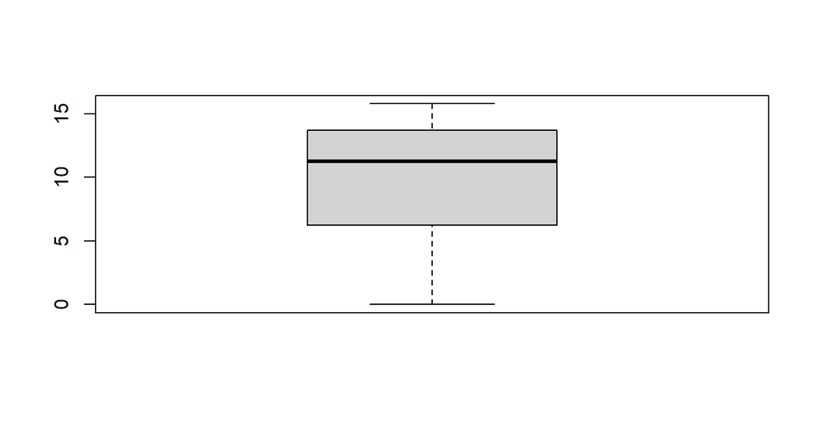

```r
boxplot(pohon$DBH)
```

- membuat *boxplot* dari *variable*/kolom ke-2 sampai dengan kolom ke-4, dengan tambahan judul dan warna.

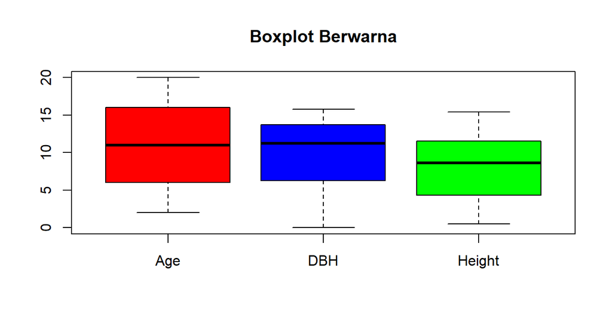

```r
boxplot(pohon[, 2:4], main = "Boxplot Berwarna", col = c("red",
    "blue", "green"))
```

**b. *Boxplot* Horisontal**

- menambah parameter `horizontal=T`.

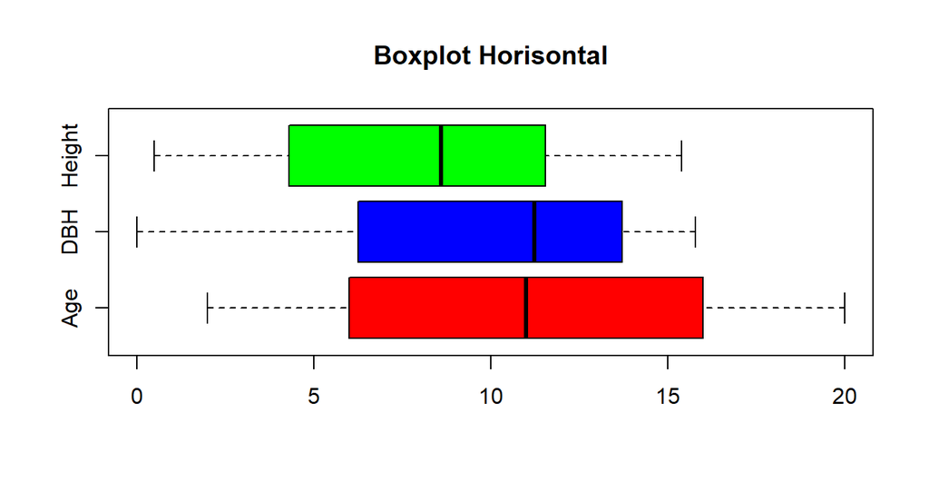

```r
boxplot(pohon[, 2:4], main = "Boxplot Horisontal", col = c("red",
    "blue", "green"), horizontal = T)
```

## 4.3 *Scatterplot*

*Scatterplot* menampilkan koleksi titik sebagai hubungan antara dua *variable*. Sintaks *scatterplot*: `plot()`.

- membuat *scatterplot* antara “Height” dan “DBH”.

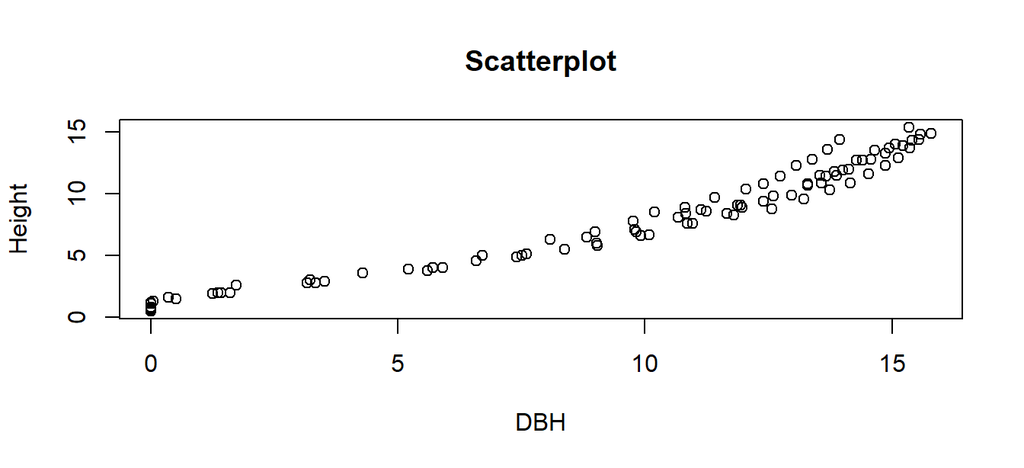

```r
plot(Height ~ DBH, pohon, main = "Scatterplot")
```

- menambahkan *lines*, dengan sintaks `abline(a=, b=)`.
  - *lines* dengan *intercept* a=0 dan *slope* b=1.
  - dan, *lines* dengan *intercept* a=0 dan *slope* b= 0.8.

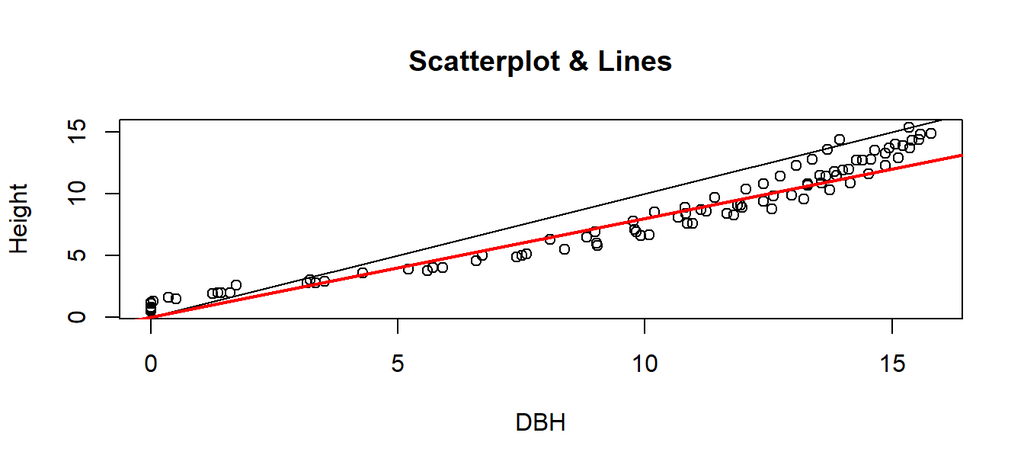

```r
plot(Height ~ DBH, pohon, main = "Scatterplot & Lines")
abline(a = 0, b = 1)
abline(a = 0, b = 0.8, col = "red", lwd = 2)
```

## 4.4 *Pairwiseplot*

*Pairwiseplot* semacam matriks dari beberapa grafik *scatterplot*.

Sintaks *pairwiseplot*: `pairs(dataset)`.

- menampilkan *pairwiseplot* dari *dataset* “pohon” untuk kolom ke-2 sampai dengan kolom ke-4.

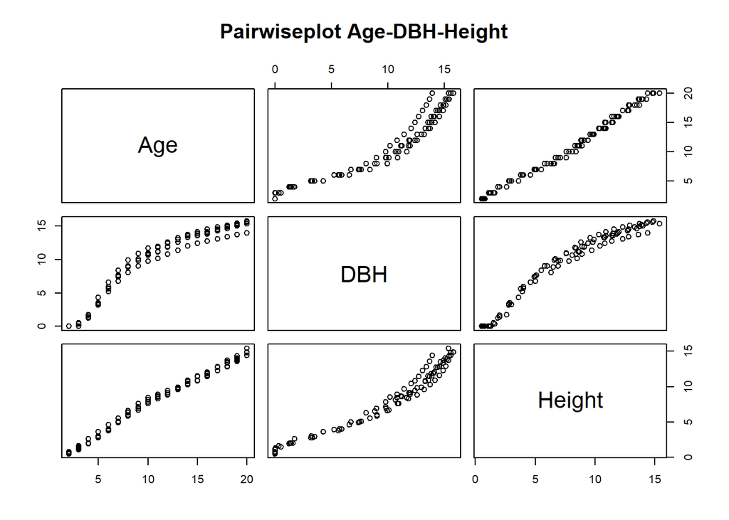

```r
pairs(pohon[, 2:4], main = "Pairwiseplot Age-DBH-Height")
```

## 4.5 Gabungan Beberapa Visualisasi Data dalam Satu Kerangka Gambar

Beberapa jenis grafik yang berbeda-beda dapat ditampilkan dalam satu kerangka (*frame*) gambar. Misal, kita ingin menampilkan 3 grafik (*histogram*, *boxplot*, dan *scatterplot*) dalam satu kerangka gambar (1 baris dengan 3 kolom).

Sintaks menyiapkan kerangka gambar: `par(mfrow=c(jumlah_baris, jumlah_kolom))`.

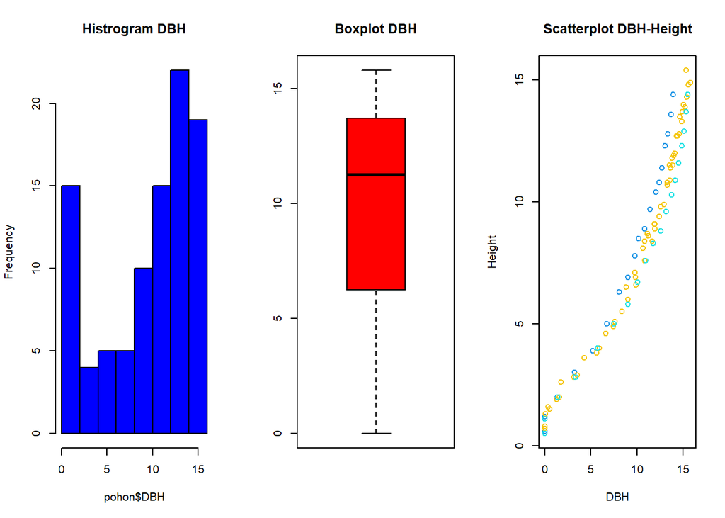

```r
par(mfrow = c(1, 3))
hist(pohon$DBH, col = "blue", main = "Histrogram DBH")
boxplot(pohon$DBH, col = "red", main = "Boxplot DBH")
plot(Height ~ DBH, pohon, main = "Scatterplot DBH-Height", col = c(treeID))
```

Kita telah mengenal pemahaman dasar dalam menampilkan beberapa pilihan visualisasi data, terutama *histogram*, *boxplot*, *scatterplot* dan *lines*.

# 5 Dasar Regresi Sederhana

Visualisasi grafik dari data sangat berguna dalam menampilkan isi dan perilaku data kita. Visualisasi juga mempermudah mengkomunikasikan data dengan pihak yang kita inginkan. Guna mendukung telaah data dengan bukti kuantitatif, Bab ini memberikan pemahaman dasar dalam melakukan regresi data. Bahasan meliputi hal-hal dasar tentang statistik, regresi linear dan regresi non-linear.

## 5.1 Dasar Statistik Deskriptif

Sesi ini sekedar untuk mengingatkan kembali tentang cara memperoleh beberapa nilai statistik deskriptif dari data.

- menghitung nilai minimal `min()` dan maksimal `max()`.

```r
min(pohon$Height)  # nilai minimum dari 'Height'
```

```
## [1] 0.5
```

```r
max(pohon$Height)  # nilai maksimum dari 'Height'
```

```
## [1] 15.4
```

- pada sesi sebelumnya, sintaks `summary()` telah dikenal, untuk menampilkan ringkasan statistik.

```r
summary(pohon$Height)
```

```
##    Min. 1st Qu.  Median    Mean 3rd Qu.    Max.
##   0.500   4.300   8.600   8.058  11.550  15.400
```

- menghitung penjumlahan (*summation*) data.

```r
sum(pohon$Height)  # penjumlahan dari 'Height'
```

```
## [1] 765.5
```

- menghitung panjang atau jumlah observasi data.

```r
length(pohon$Height)  # jumlah observasi dari 'Height'
```

```
## [1] 95
```

- menghitung *variance*, *standard deviation*, *covariance*, dan *correlation*.

```r
var(pohon$Height)  # variance
```

```
## [1] 18.71395
```

```r
sd(pohon$Height)  # standard deviation
```

```
## [1] 4.325963
```

```r
cov(pohon$Height, pohon$DBH)  # covariance
```

```
## [1] 21.18354
```

```r
cor(pohon$Height, pohon$DBH)  # correlation
```

```
## [1] 0.9687732
```

Sesi selanjutnya menyajikan pembahasan model regresi sederhana, baik regresi *linear* maupun regresi *non-linear*.

## 5.2 *Linear Model (lm)*

Model linear dapat terdiri dari *independent variable* tunggal (*simple linear model*) atau *independent variable* yang lebih dari satu (*multiple linear model*).

### 5.2.1 *Simple Linear Model*

Model teoretis (*theoretical model*) dari model *linear* tunggal seperti di bawah ini.
$$Y = \alpha + \beta X$$
Pada sesi visualisasi, kita telah mengenal sintaks `abline(a=, b=)`, dimana nilai “a” adalah *intercept*, dan nilai “b” adalah *slope*. Dalam fungsi *linear* tunggal di atas, $\alpha$ = “a” = *intercept*; dan $\beta$ = “b” = *slope*.

Latihan kasus di bawah ini ingin membangun model *linear* tunggal, untuk melihat pengaruh *variable* “DBH” terhadap *variable* “Height”. Dengan demikian, model empiris (*empirical model*) *linear* tunggalnya dituliskan sebagai berikut.
$$Height = \alpha + \beta DBH$$
Data yang digunakan bersumber dari *dataset* “pohon”. Namun demikian, kita hanya membatasi pada kelompok pohon ke-7 (“treeID=7”).

- mengekstrak dan membentuk *dataset* baru (“pohon7”), yang berisi seluruh *variable* dari pohon kelompok ke-7.
  - sintaks untuk *slicing*: `dataset[baris ke-, kolom ke-]`.

```r
pohon7 <- pohon[pohon$treeID == 7, ]
```

- meninjau ringkasan *dataset* “pohon7”.

```r
head(pohon7)
```

|  | treeID | Age | DBH | Height | Volume |
| --- | --- | --- | --- | --- | --- |
| 1 | 7 | 2 | 0.00 | 0.7 | 0.000 |
| 2 | 7 | 3 | 0.35 | 1.6 | 0.000 |
| 3 | 7 | 4 | 1.73 | 2.6 | 0.001 |
| 4 | 7 | 5 | 4.29 | 3.6 | 0.004 |
| 5 | 7 | 6 | 6.59 | 4.6 | 0.010 |
| 6 | 7 | 7 | 8.38 | 5.5 | 0.018 |

```r
tail(pohon7)
```

|  | treeID | Age | DBH | Height | Volume |
| --- | --- | --- | --- | --- | --- |
| 14 | 7 | 15 | 13.88 | 11.5 | 0.090 |
| 15 | 7 | 16 | 14.12 | 12.0 | 0.098 |
| 16 | 7 | 17 | 14.57 | 12.8 | 0.110 |
| 17 | 7 | 18 | 14.94 | 13.7 | 0.122 |
| 18 | 7 | 19 | 15.41 | 14.3 | 0.135 |
| 19 | 7 | 20 | 15.79 | 14.9 | 0.148 |

- menampilkan visualisasi hubungan “DBH” dan “Height”.

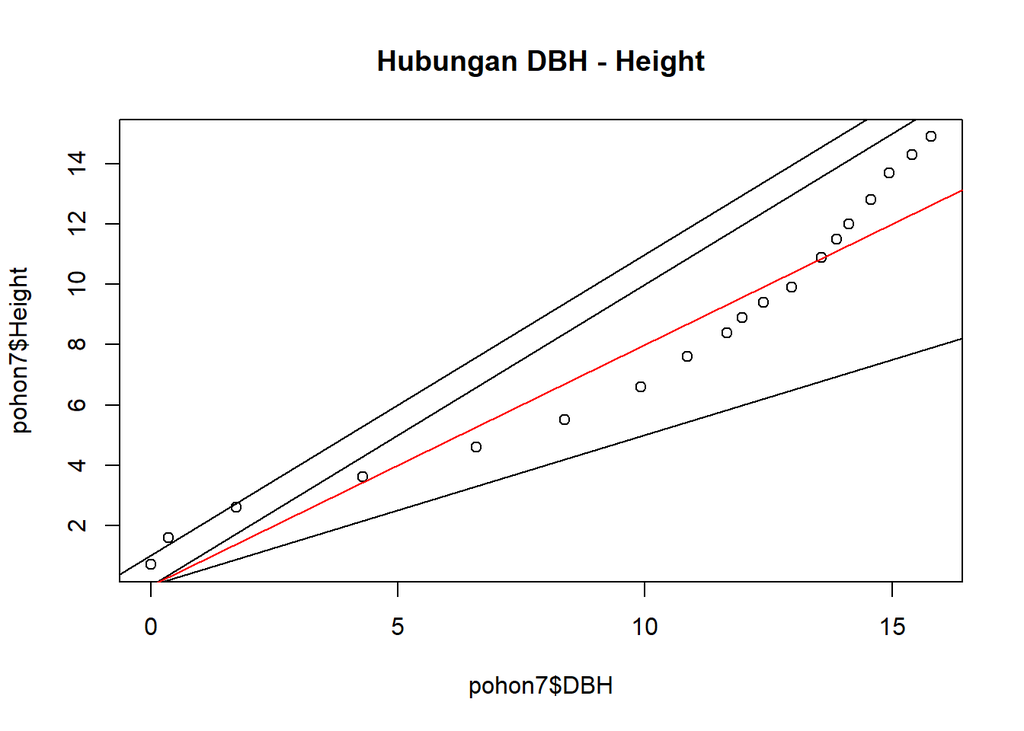

```r
plot(pohon7$DBH, pohon7$Height, main = "Hubungan DBH - Height")
abline(a = 0, b = 1)
abline(a = 0, b = 0.5)
abline(a = 1, b = 1)
abline(a = 0, b = 0.8, col = "red")
```

- sintaks model *linear* tunggal sebagai berikut.  
  `lm(Y~X, data="nama_dataset")`
- menjalankan model *lm* antara *variable* “Height” dan variable “DBH”.
  - hasilnya, kita *assign* sebagai *variable* bernama “lm_pohon7”.

```r
lm_pohon7 <- lm(Height ~ DBH, data = pohon7)
lm_pohon7
```

```
##
## Call:
## lm(formula = Height ~ DBH, data = pohon7)
##
## Coefficients:
## (Intercept)          DBH
##      0.0717       0.8177
```

- model di atas menghasilkan nilai di bawah ini.
  - $\alpha$ = *intercept* = a = 0.0717.
  - $\beta$ = *slope* = b = 0.8177.
  - sehingga hasil model empirisnya adalah sebagai berikut.
    $$Height = 0.0717 + 0.8177 DBH$$
- menampilkan visualiasi hasil model.

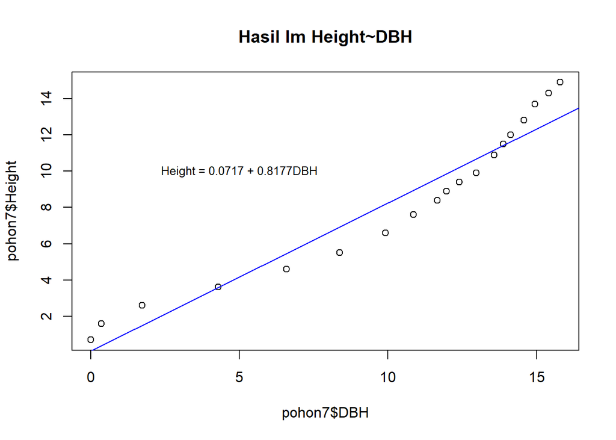

```r
plot(pohon7$DBH, pohon7$Height, main = "Hasil lm Height~DBH")
abline(lm_pohon7, col = "blue")
text(5, 10, "Height = 0.0717 + 0.8177DBH", cex = 0.8)
```

- menampilkan ringkasan dari hasil model.

```r
summary(lm_pohon7)
```

```
##
## Call:
## lm(formula = Height ~ DBH, data = pohon7)
##
## Residuals:
##      Min       1Q   Median       3Q      Max
## -1.58300 -0.90969  0.02049  0.96427  1.91727
##
## Coefficients:
##             Estimate Std. Error t value Pr(>|t|)
## (Intercept)  0.07170    0.60300   0.119    0.907
## DBH          0.81767    0.05309  15.402 2.03e-11 ***
## ---
## Signif. codes:  0 '***' 0.001 '**' 0.01 '*' 0.05 '.' 0.1 ' ' 1
##
## Residual standard error: 1.166 on 17 degrees of freedom
## Multiple R-squared:  0.9331, Adjusted R-squared:  0.9292
## F-statistic: 237.2 on 1 and 17 DF,  p-value: 2.034e-11
```

- menampilkan visualisasi model.

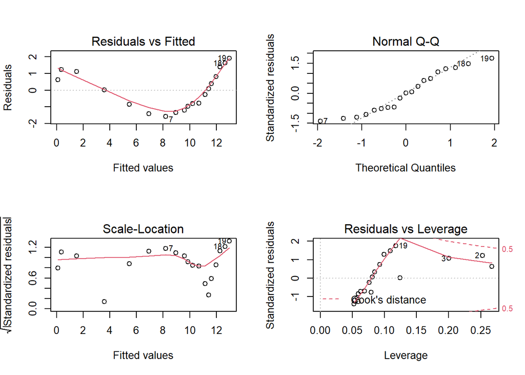

```r
par(mfrow = c(2, 2))  # menyiapkan kerangka grafik: 2 baris dan 2 kolom
plot(lm_pohon7)
```

### 5.2.2 *Multiple Linear Model*

*Multiple linear model* mempunyai *independent variable* lebih dari satu. Model teoretis (*theoretical model*) dari *multiple linear model* adalah sebagai berikut.
$$Y = \alpha + \beta_1X_1 + \beta_2X_2$$
Latihan di bawah ini menggunakan *dataset* “pohon”, untuk menelaah *variables* yang mempengaruhi “Volume”.

- dari sintaks `cor()`, kita bisa menampilkan keterhubungan (*correlation*) antar *variable*.

```r
cor(pohon)
```

```
##             treeID       Age        DBH      Height      Volume
## treeID  1.00000000 0.0000000 0.01538271 -0.02549617 -0.04616717
## Age     0.00000000 1.0000000 0.94567643  0.99424875  0.97336552
## DBH     0.01538271 0.9456764 1.00000000  0.96877317  0.88701431
## Height -0.02549617 0.9942488 0.96877317  1.00000000  0.96358634
## Volume -0.04616717 0.9733655 0.88701431  0.96358634  1.00000000
```

Agar lebih sederhana, kita membatasi pada dua *independent variable* (“DBH” dan “Height”) terhadap “Volume”, dengan model empiris sebagai berikut.
$$Volume = \alpha + \beta_1DBH + \beta_2Height$$

- sintaks *multiple linear model* sebagai berikut.  
  `lm(Y~X1+X2, data="nama_dataset")`
- menjalankan dan menyimpan model empiris *lm* tidak tunggal, dengan nama “lmm_pohon”.

```r
lmm_pohon <- lm(Volume ~ DBH + Height, data = pohon)
lmm_pohon
```

```
##
## Call:
## lm(formula = Volume ~ DBH + Height, data = pohon)
##
## Coefficients:
## (Intercept)          DBH       Height
##   -0.023080    -0.006463     0.016939
```

```r
summary(lmm_pohon)
```

```
##
## Call:
## lm(formula = Volume ~ DBH + Height, data = pohon)
##
## Residuals:
##        Min         1Q     Median         3Q        Max
## -0.0207555 -0.0043590  0.0007435  0.0047002  0.0207307
##
## Coefficients:
##               Estimate Std. Error t value Pr(>|t|)
## (Intercept) -0.0230801  0.0018503  -12.47  < 2e-16 ***
## DBH         -0.0064626  0.0006853   -9.43 3.61e-15 ***
## Height       0.0169392  0.0008007   21.15  < 2e-16 ***
## ---
## Signif. codes:  0 '***' 0.001 '**' 0.01 '*' 0.05 '.' 0.1 ' ' 1
##
## Residual standard error: 0.008327 on 92 degrees of freedom
## Multiple R-squared:  0.9636, Adjusted R-squared:  0.9629
## F-statistic:  1219 on 2 and 92 DF,  p-value: < 2.2e-16
```

Dari hasil di atas, maka hasil model empirisnya adalah sebagai berikut.
$$Volume = -0.023080 - 0.006463 DBH + 0.016939 Height$$

- menampilkan visualisasi dari hasil model empiris.

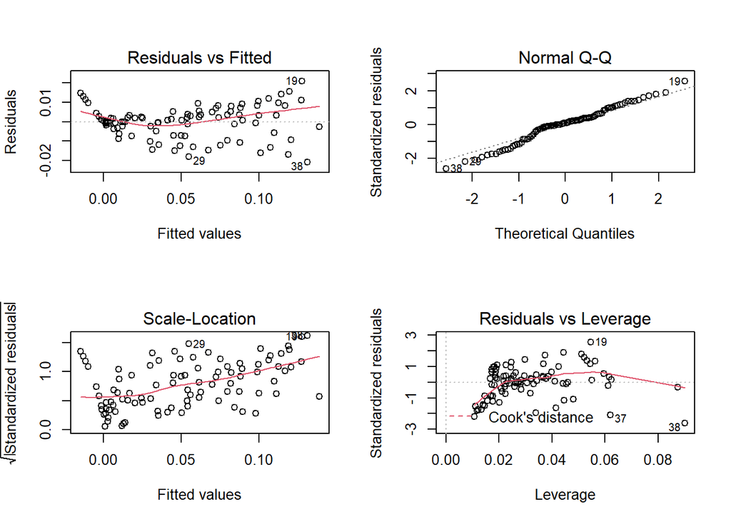

```r
par(mfrow = c(2, 2))
plot(lmm_pohon)
```

## 5.3 *Nonlinear Model - Nonlinear Least Square (nls)*

Pada beberapa kasus, hubungan antara *independent variable X* dan *dependent variable Y* tidak selalu bersifat *linear*. Sesi ini menyajikan dasar pemahaman terhadap *non-linear model*.

Latihan menggunakan kembali *dataset* “pohon7”. Dan, telaah difokuskan pada keterhubungan antara “Age” (sebagai *independent variable*) dan “DBH” (sebagai *dependent variable*).

- menginspeksi *dataset* “pohon7”.

```r
head(pohon7)
```

|  | treeID | Age | DBH | Height | Volume |
| --- | --- | --- | --- | --- | --- |
| 1 | 7 | 2 | 0.00 | 0.7 | 0.000 |
| 2 | 7 | 3 | 0.35 | 1.6 | 0.000 |
| 3 | 7 | 4 | 1.73 | 2.6 | 0.001 |
| 4 | 7 | 5 | 4.29 | 3.6 | 0.004 |
| 5 | 7 | 6 | 6.59 | 4.6 | 0.010 |
| 6 | 7 | 7 | 8.38 | 5.5 | 0.018 |

Terlihat bahwa baris ke-1 dan ke-2 mempunyai nilai “Volume” = 0, sehingga kita tidak ingin menggunakan data baris ke-1 dan ke-2.

- mengekstrak dan membuat *dataset* baru (dinamakan “pohon71”), yang berisi seluruh dari dari *dataset* “pohon7” yang mempunyai “Volume”>0.

```r
pohon71 <- pohon7[pohon7$Volume > 0, ]  # mengekstrak dataset 'pohon7'
# yang 'Volume'>0
head(pohon71)
```

|  | treeID | Age | DBH | Height | Volume |
| --- | --- | --- | --- | --- | --- |
| 3 | 7 | 4 | 1.73 | 2.6 | 0.001 |
| 4 | 7 | 5 | 4.29 | 3.6 | 0.004 |
| 5 | 7 | 6 | 6.59 | 4.6 | 0.010 |
| 6 | 7 | 7 | 8.38 | 5.5 | 0.018 |
| 7 | 7 | 8 | 9.92 | 6.6 | 0.027 |
| 8 | 7 | 9 | 10.86 | 7.6 | 0.035 |

- menampilkan visualisasi hubungan “Age” dan “DBH”.

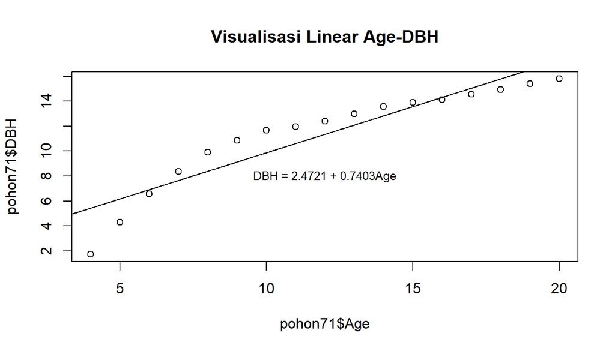

```r
plot(pohon71$Age, pohon71$DBH, main = "Visualisasi Linear Age-DBH")
lm_pohon71 <- lm(DBH ~ Age, data = pohon71)
abline(lm_pohon71)
text(12, 8, "DBH = 2.4721 + 0.7403Age", cex = 0.8)
```

Terlihat bahwa sebaran observasi bersifat *sigmoid*, dan terlihat bahwa *linear model* kurang sesuai untuk memodelkan hubungan antara *Age* dan *DBH*.

- salah satu model *non-linear sigmoid curve* atau *growth analysis* adalah *Bertalanffy function*, dengan model teoretis sebagai berikut.
  $$Y = \alpha(1-e^{-\beta X})^3$$

Dengan demikian, model empiris yang dibangun adalah sebagai berikut.
$$DBH = \alpha(1-e^{-\beta Age})^3$$

- menampilkan visualisasi *scatterplot* dari kedua *variables*.
- dan, melakukan *trial and error* untuk mencari nilai $\alpha$ (“a”) dan nilai $\beta$ (“b”) yang paling mendekati.

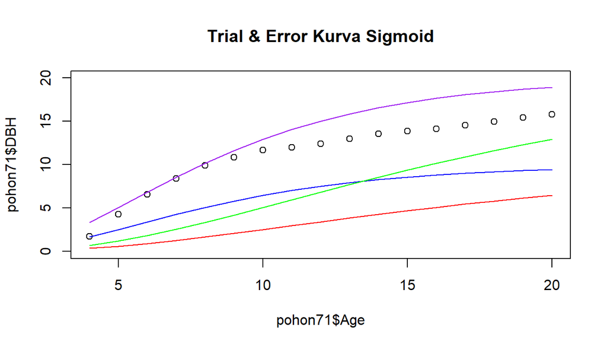

```r
plot(pohon71$Age, pohon71$DBH, ylim = c(0, 20), main = "Trial & Error Kurva Sigmoid")

y1 <- 10 * (1 - exp(-0.1 * pohon71$Age))^3
lines(pohon71$Age, y1, col = "red")

y2 <- 10 * (1 - exp(-0.2 * pohon71$Age))^3
lines(pohon71$Age, y2, col = "blue")

y3 <- 20 * (1 - exp(-0.1 * pohon71$Age))^3
lines(pohon71$Age, y3, col = "green")

y4 <- 20 * (1 - exp(-0.2 * pohon71$Age))^3
lines(pohon71$Age, y4, col = "purple")
```

Terlihat bahwa *lines* yang paling mendekati observasi adalah *lines* dengan nilai a=20 dan b=0.2 (garis warna ungu).

- menjalankan model empiris dengan menggunakan nilai a dan b di atas.

```r
nls_bert_pohon71 <- nls(pohon71$DBH ~ a * (1 - exp(-b * pohon71$Age))^3,
    data = pohon71, start = list(a = 20, b = 0.2))
nls_bert_pohon71
```

```
## Nonlinear regression model
##   model: pohon71$DBH ~ a * (1 - exp(-b * pohon71$Age))^3
##    data: pohon71
##       a       b
## 15.7731  0.2244
##  residual sum-of-squares: 5.138
##
## Number of iterations to convergence: 4
## Achieved convergence tolerance: 1.763e-06
```

```r
summary(nls_bert_pohon71)
```

```
##
## Formula: pohon71$DBH ~ a * (1 - exp(-b * pohon71$Age))^3
##
## Parameters:
##    Estimate Std. Error t value Pr(>|t|)
## a 15.773137   0.324666   48.58  < 2e-16 ***
## b  0.224413   0.007923   28.32 1.94e-14 ***
## ---
## Signif. codes:  0 '***' 0.001 '**' 0.01 '*' 0.05 '.' 0.1 ' ' 1
##
## Residual standard error: 0.5853 on 15 degrees of freedom
##
## Number of iterations to convergence: 4
## Achieved convergence tolerance: 1.763e-06
```

Dari hasil tersebut, maka hasil model empirisnya adalah sebagai berikut.
$$DBH = 15.7731(1-e^{-0.2244 Age})^3$$

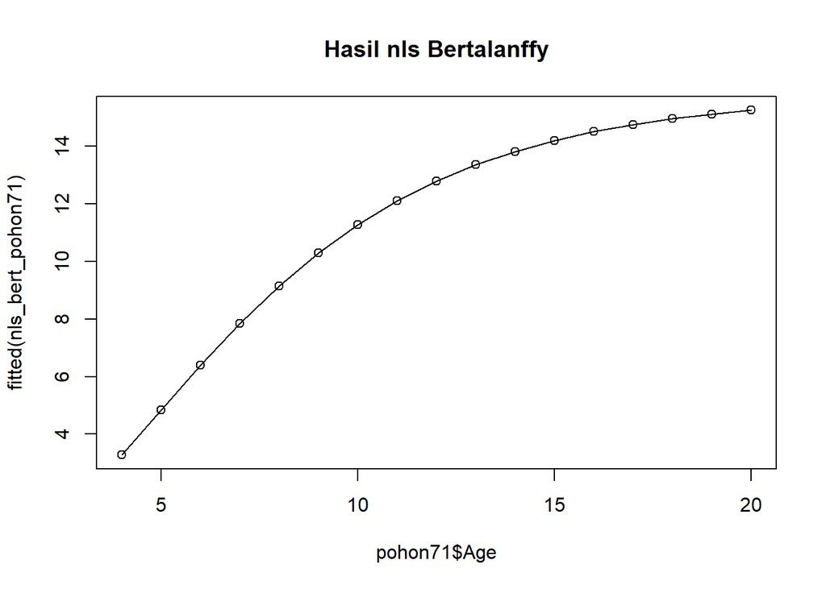

```r
plot(pohon71$Age, fitted(nls_bert_pohon71), type = "o", main = "Hasil nls Bertalanffy")
```

# Catatan Penutup

Sebagaimana judulnya, *Dasar R*, buku/modul ini menyajikan hal-hal dasar tentang bahasa *R*. Juga, materi yang disajikan relatif sederhana, dengan hanya memanfaatkan kapasitas *built-in* yang sudah ada di bahasa *R*, tanpa menambahkan suatu *modul* atau *package* tambahan. Selain itu, latihan-latihan juga hanya menggunakan satu *dataset* dari awal sampai akhir. Harapannya, buku/modul ini bisa memberikan pengenalan awal sehingga siapapun bisa menikmati percakapan dengan bahasa *R*.

Ke depan, sangat dimungkinkan untuk dilakukan pemutakhiran (*updating*) materi, baik berupa penambahan, koreksi, modifikasi atau bahkan pengurangan, untuk lebih menyesuaikan kebutuhan pengguna. Oleh karena itu, kritikan dan masukan sangat dinantikan melalui email: **j.indarto@gmail.com**. Buku/modul dan data latihan juga disediakan secara bebas di situs **https://indarto.weebly.com** ini.

*Alhamdulillaahirrabbiláalamiin…*

[^1]: Bekerja di Kementerian Perencanaan Pembangunan Nasional/BAPPENAS; email: **indarto@bappenas.go.id** dan **j.indarto@gmail.com**; situs: **https://indarto.weebly.com**.
[^2]: Bahan utama bersumber dari “*R Workbook*, bahan pelatihan R, PERHEPI Indonesia - *the Institute of Statistical Mathematics (ISM)* Jepang, 21-23 Desember 2020”.
[^3]: Terima kasih kepada Perhimpunan Ekonomi Pertanian Indonesia (PERHEPI) dan *the Institute of Statistical Mathematics (ISM)* Jepang yang memfasilitasi pelatihan ini.
[^4]: CRAN: *the Comprehensive R Archive Network*.
[^5]: *IDE (Integrated Development Environment)*: perangkat lunak atau program sebagai wadah/lingkungan yang mempermudah pelaksanaan pemrograman.
[^6]: *Notebook* atau *notebook document* merupakan *platform* yang mampu memadukan antara pengkodean (penulisan kode, menjalankan kode, dan hasil pengkodean, termasuk visualisasi data), dengan narasi teks, penulisan karakter matematika, dan media lain dalam satu dokumen.
[^7]: Dalam situs resminya, yang kami akses pada 30-Desember-2020, diberikan pengumuman sebagai berikut: “*The Azure Notebooks preview will be retired on January 15th, 2021, and all user data will be destroyed. Please download your user data before then. To execute notebooks or create new notebook content, learn about our other notebooks experiences at Microsoft*”. Saat ini, *Microsoft* mengembangkan beberapa *platform* layanan, antara lain: *Visual Code*, *Github Codespace*, *Azure Machine Learning*, maupun *Azure Lab*. Pilihan layanan tersebut dapat diakses di sini: https://notebooks.azure.com/Content/alternatives.html.
[^8]: Topik tentang pembuatan data, konversi tipe dan format data, penggalian data (*data mining*), dan lain-lain, belum dibahas dalam buku/modul ini.
[^9]: *Comma Separated Values*, kadang disebut *Character Separated Values* atau *Comma Delimited File*, merupakan format *file* dalam bentuk teks dimana data disimpan dan dipisahkan dengan tanda tertentu (koma, titik koma, *tab*, dan lain-lain)
[^10]: *Dataframe* merupakan salah satu bentuk *R-objects*. Beberapa jenis *R-objects*, antara lain: *vectors*, *lists*, *matrices*, *arrays*, *factors*, dan *dataframe*. Pilihan *R-objects* tersebut, memungkinkan pengguna dalam memilih kelas *dataset* yang sesuai untuk menyimpan datanya. Buku/modul ini tidak membahas jenis *R-objects* tersebut; namun, sangat disarankan untuk dipelajari lebih lanjut.